# 검색 증강 생성(RAG)

## 평가

```python
# Initialize the SummaryIndexedVectorDB
level_three_db = SummaryIndexedVectorDB("anthropic_docs_v3")
level_three_db.load_data("data/anthropic_summary_indexed_docs.json")

import pandas as pd

# Run the evaluations
avg_precision, avg_recall, avg_mrr, f1, precisions, recalls, mrrs = evaluate_retrieval(
    retrieve_advanced, eval_data, level_three_db
)
e2e_accuracy, e2e_results = evaluate_end_to_end(answer_query_advanced, level_two_db, eval_data)

# Create a DataFrame
df = pd.DataFrame(
    {
        "question": [item["question"] for item in eval_data],
        "retrieval_precision": precisions,
        "retrieval_recall": recalls,
        "retrieval_mrr": mrrs,
        "e2e_correct": e2e_results,
    }
)

# Save to CSV
df.to_csv("evaluation/csvs/evaluation_results_detailed_level_three.csv", index=False)
print("Detailed results saved to evaluation_results_detailed_level_three.csv")

# Plot the results
# Print the results
print(f"Average Precision: {avg_precision:.4f}")
print(f"Average Recall: {avg_recall:.4f}")
print(f"Average F1: {f1:.4f}")
print(f"Average Mean Reciprocal Rank: {avg_mrr:4f}")
print(f"End-to-End Accuracy: {e2e_accuracy:.4f}")

# Save the results to a file
with open("evaluation/json_results/evaluation_results_level_three.json", "w") as f:
    json.dump(
        {
            "name": "Summary Indexing + Re-Ranking",
            "average_precision": avg_precision,
            "average_recall": avg_recall,
            "average_f1": f1,
            "average_mrr": avg_mrr,
            "end_to_end_accuracy": e2e_accuracy,
        },
        f,
        indent=2,
    )

print(
    "Evaluation complete. Results saved to evaluation_results_level_three.json, evaluation_results_detailed_level_three.csv, and evaluation_results_level_three.png"
)
```

```
Loading vector database from disk.
```

[output not shown]

[output not shown]

[output not shown]

[output not shown]

[output not shown]

[output not shown]

[output not shown]

[output not shown]

[output not shown]

[output not shown]

```
2,0,1
[2, 0, 1]
Processed 10/100 items. Current Avg Precision: 0.5000, Avg Recall: 0.8000, Avg MRR: 1.0000
20
```

[output not shown]

[output not shown]

[output not shown]

[output not shown]

[output not shown]

[output not shown]

[output not shown]

[output not shown]

[output not shown]

```
0,17,18
[0, 17, 18]
Processed 20/100 items. Current Avg Precision: 0.4333, Avg Recall: 0.7250, Avg MRR: 0.9667
9
```

[output not shown]

[output not shown]

[output not shown]

[output not shown]

[output not shown]

[output not shown]

[output not shown]

[output not shown]

[output not shown]

```
0, 4, 7
[0, 4, 7]
Processed 30/100 items. Current Avg Precision: 0.4556, Avg Recall: 0.7389, Avg MRR: 0.9611
9
```

[output not shown]

[output not shown]

[output not shown]

[output not shown]

[output not shown]

[output not shown]

[output not shown]

[output not shown]

[output not shown]

```
2,6,16
[2, 6, 16]
Processed 40/100 items. Current Avg Precision: 0.4583, Avg Recall: 0.7167, Avg MRR: 0.9042
20
```

[output not shown]

[output not shown]

[output not shown]

[output not shown]

[output not shown]

[output not shown]

[output not shown]

[output not shown]

[output not shown]

```
0,1,2
[0, 1, 2]
Processed 50/100 items. Current Avg Precision: 0.4400, Avg Recall: 0.7033, Avg MRR: 0.8800
8
```

[output not shown]

[output not shown]

[output not shown]

[output not shown]

[output not shown]

[output not shown]

[output not shown]

[output not shown]

[output not shown]

```
1, 5, 15
[1, 5, 15]
Processed 60/100 items. Current Avg Precision: 0.4444, Avg Recall: 0.7194, Avg MRR: 0.8889
6
```

[output not shown]

[output not shown]

[output not shown]

[output not shown]

[output not shown]

[output not shown]

[output not shown]

[output not shown]

[output not shown]

```
0,1,14
[0, 1, 14]
Processed 70/100 items. Current Avg Precision: 0.4333, Avg Recall: 0.7024, Avg MRR: 0.8667
6
```

[output not shown]

[output not shown]

[output not shown]

[output not shown]

[output not shown]

[output not shown]

[output not shown]

[output not shown]

[output not shown]

```
0,1,10
[0, 1, 10]
Processed 80/100 items. Current Avg Precision: 0.4375, Avg Recall: 0.7083, Avg MRR: 0.8583
12
```

[output not shown]

[output not shown]

[output not shown]

[output not shown]

[output not shown]

[output not shown]

[output not shown]

[output not shown]

[output not shown]

```
0,1,3
[0, 1, 3]
Processed 90/100 items. Current Avg Precision: 0.4333, Avg Recall: 0.7000, Avg MRR: 0.8685
6
```

[output not shown]

[output not shown]

[output not shown]

[output not shown]

[output not shown]

[output not shown]

[output not shown]

[output not shown]

[output not shown]

```
0,3,8
[0, 3, 8]
Processed 100/100 items. Current Avg Precision: 0.4367, Avg Recall: 0.6933, Avg MRR: 0.8650
```

[output not shown]

```
<content>
<explanation>The Generated Answer is correct. It captures the key elements from the Correct Answer - namely that you can create multiple test cases by clicking the 'Add Test Case' button and filling in values for variables in your prompt, then repeating this process for additional test cases. The Ge…
<is_correct>true</is_correct>
</content>

15
0,1,2
[0, 1, 2]
```

```
<content>
<explanation>The Generated Answer is correct. It captures the key points from the Correct Answer:
1. It correctly identifies Voyage AI as Anthropic's recommended embeddings provider
2. It mentions that Voyage AI offers customized/domain-specific models (including specific examples for finance and healthcare)
3. It notes that Voyage AI provides bespoke fine-tuned models for individual customers

While the Generated Answer provides more specific details about Voyage AI's model offerings than the Correct Answer, this additional information doesn't contradict anything in the Correct Answer - it simply elaborates further. The core substance and main points are aligned between both answers.</exp…
<is_correct>true</is_correct>
</content>

20
1,13,15
[1, 13, 15]
```

```
<content>
<explanation>The Generated Answer is correct as it covers all the key points mentioned in the Correct Answer and even provides additional helpful details. Both answers mention the same core success metrics: accuracy, F1 score, consistency, structure, speed, and bias/fairness. Both answers also empha…
<is_correct>true</is_correct>
</content>

20
0,1,6
[0, 1, 6]
```

```
<content>
<explanation>The Generated Answer is correct as it captures the same two key advantages of Claude for Sheets mentioned in the Correct Answer:

1. Both answers highlight the ability to test prompts in parallel across evaluation suites, noting this is more efficient than sequential chained prompts.

2. Both answers mention that Claude for Sheets is better suited for office tasks like survey analysis and data processing compared to chained prompts.

The Generated Answer expresses these same core concepts, just with slightly different wording and structure. There are no missing critical pieces of information or contradictions between the two answers.</explanation>
<is_correct>true</is_correct>
</content>

9
0,1,2
[0, 1, 2]
```

```
<content>
<explanation>The Generated Answer is correct. Both answers convey the same core information - that missing "\n\nHuman:" and "\n\nAssistant:" turns in the Text Completions API prompt will result in an API error. The Generated Answer provides some additional context about formatting and ordering, but …
<is_correct>true</is_correct>
</content>

11
0,1,2
[0, 1, 2]
```

```
<content>
<explanation>The Generated Answer is correct. It captures all the key points from the Correct Answer and even provides more detailed information while maintaining the same core message. Both answers emphasize that:

1. Tool use requests are priced based on total input and output tokens, just like regular requests
2. There are additional tokens required for tool use, including:
   - The tools parameter
   - Tool use content blocks
   - Tool result content blocks
   - Special system prompt

The Generated Answer expands on these points with more detail but doesn't contradict or omit any critical information from the Correct Answer. The fundamental message about how tool use affects pricing (by adding more tokens that are counted in the same way as regular requests) is consistent between…
<is_correct>true</is_correct>
</content>

20
0,5,11
[0, 5, 11]
```

```
<content>
<explanation>The Generated Answer is correct. It contains all the essential information from the Correct Answer - specifically the release date (June 27th, 2024) and what features will be available (API usage, billing details, and rate limits). While the Correct Answer provides slightly more detail …
<is_correct>true</is_correct>
</content>

9
0,1,7
[0, 1, 7]
```

```
<content>
<explanation>The Generated Answer is correct as it captures both key elements from the Correct Answer:

1. It mentions considering whether the task requires in-depth thinking/complex reasoning (matching the Correct Answer's point about "tasks requires in-depth thinking that a human would need to work through")

2. It acknowledges that CoT increases output length which impacts latency (matching the Correct Answer's point about "increased output length from CoT may impact latency")

The Generated Answer actually provides more detail and examples, but the core substance aligns perfectly with the Correct Answer. There are no contradictions or missing critical pieces of information between the two answers.</explanation>
<is_correct>true</is_correct>
</content>

20
1,19,10
[1, 19, 10]
```

```
<content>
<explanation>The Generated Answer is correct. While it provides much more detailed steps and technical implementation details, at its core it conveys the same fundamental concept as the Correct Answer - that Claude can be used to process and summarize PDF documents to make them easier to understand.…
<is_correct>true</is_correct>
</content>

10
2,0,1
[2, 0, 1]
```

```
<content>
<explanation>The Generated Answer is correct. Both answers indicate that you can view the API rate limits in a Rate Limits tab within Anthropic's console interface. The only difference is minor wording variation ("Developer Console" vs "Claude Console") and the Generated Answer's inclusion of the wo…
<is_correct>true</is_correct>
</content>

Processed 10/100 questions. Current Accuracy: 1.0000
20
0,4,11
[0, 4, 11]
```

```
<content>
<explanation>The Generated Answer is correct. While it provides many additional metrics beyond what is mentioned in the Correct Answer, it does include the two key metrics specified in the Correct Answer: the 95th percentile response time (mentioned under "Speed") and cost per classification (mentio…
<is_correct>true</is_correct>
</content>

8
0,3,2
[0, 3, 2]
```

```
<content>
<explanation>The Generated Answer is correct. It captures the key distinction between how system prompts are specified in both APIs:

1. For Text Completions API: Both answers indicate that the system prompt goes before the first "\n\nHuman:" turn in the prompt text
2. For Messages API: Both answers specify that the system prompt is set using a dedicated "system" parameter in the API request

The Generated Answer actually provides helpful concrete examples to illustrate these concepts, which goes beyond but doesn't contradict the Correct Answer. The substance and core information about how to specify system prompts in both APIs is consistent between both answers.</explanation>
<is_correct>true</is_correct>
</content>

20
4,3,6
[4, 3, 6]
```

[output not shown]

```
<content>
<explanation>
The Generated Answer is essentially correct and aligns with the core message of the Correct Answer. Both answers emphasize:

1. The use of XML tags (like <thinking> and <answer>) to structure prompts
2. The combination of these tags with chain of thought reasoning
3. The goal of creating high-performance, structured prompts for Claude

While the Generated Answer goes into more detail about specific implementation aspects (like nesting tags and maintaining consistency), and the Correct Answer provides a more specific example of how to prompt Claude, the fundamental concept being conveyed is the same. The Generated Answer doesn't co…

The additional details provided in the Generated Answer serve to expand on the core concept rather than contradict or omit any critical information from the Correct Answer.
</explanation>
<is_correct>true</is_correct>
</content>

20
9,5,0
[9, 5, 0]
```

```
<content>
<explanation>The Generated Answer is correct. It contains all the same key information as the Correct Answer, just presented in a slightly different format:

1. Both answers identify the same three metrics being measured
2. Both provide the exact same values for each metric:
   - 89.01% accuracy
   - 1.61 seconds for 95th percentile response time
   - $0.0004 for average cost per request/classification

The only difference is in minor wording choices (e.g., "Classification" vs "request routing") which doesn't affect the substantive meaning. The Generated Answer captures all the critical information from the Correct Answer without any contradictions or omissions.</explanation>
<is_correct>true</is_correct>
</content>

20
2,7,13
[2, 7, 13]
```

```
<content>
<explanation>The Generated Answer is correct. It contains all the key elements from the Correct Answer:
1. Having clear success criteria
2. Having ways to empirically test against those criteria
3. Having a first draft prompt to improve

The Generated Answer actually provides slightly more detail by mentioning specific documentation sections, but the core substance perfectly matches the Correct Answer. There are no contradictions or missing critical pieces of information. The minor differences in phrasing (like listing the items wit…
<is_correct>true</is_correct>
</content>

7
1,2,0
[1, 2, 0]
```

```
<content>
<explanation>The Generated Answer is correct. While it provides more detail and context than the Correct Answer, it contains the key information about how mid-response prompting works in both APIs:

1. For the Text Completions API, it correctly states that you can "pre-fill part of Claude's response by including it in the prompt"

2. For the Messages API, it correctly explains that you can "make the last input message have the assistant role, and the response will continue from that content"

These points align perfectly with the substance of the Correct Answer. The additional information about streaming, input/output formats, and other differences between the APIs doesn't contradict the core information, it just provides extra context. Since there are no missing critical pieces of infor…
<is_correct>true</is_correct>
</content>

19
1,4,3
[1, 4, 3]
```

```
<content>
<explanation>The Generated Answer is correct. Both answers convey the same core message that when given a role through a system prompt (specifically as CFO), Claude provides more detailed, structured, and actionable financial analysis compared to not having a specific role. The Generated Answer actu…
<is_correct>true</is_correct>
</content>

9
1,5,3
[1, 5, 3]
```

```
<content>
<explanation>The Generated Answer is correct as it covers all the essential elements from the Correct Answer and even provides additional relevant details. Both answers mention:

1. Key quantitative metrics including F1 score, accuracy, precision, and recall
2. The importance of using industry benchmarks, prior experiments, AI research, and expert knowledge to determine specific targets
3. The concept of improvement over baseline

The Generated Answer actually goes into more detail by providing specific examples (like the F1-score target of 0.85) and additional metrics like perplexity and operational metrics. While these details aren't in the Correct Answer, they don't contradict it and only serve to enhance the core message.…
<is_correct>true</is_correct>
</content>

5
0,1,3
[0, 1, 3]
```

[output not shown]

```
<content>
<explanation>The Generated Answer is correct. It captures the key elements from the Correct Answer:
1. The core concept of combining XML tags with other prompt engineering techniques
2. Specifically mentions multishot prompting using <examples> tags
3. Mentions chain of thought using <thinking> and <answer> tags
4. Notes that this creates "super-structured, high-performance prompts"

While the wording is slightly different, the substance and meaning are identical. There are no missing critical pieces of information and no contradictions between the two answers.</explanation>
<is_correct>true</is_correct>
</content>

20
0,17,18
[0, 17, 18]
```

```
<content>
<explanation>The Generated Answer is correct as it captures the essential elements from the Correct Answer and even provides additional helpful implementation details. Both answers emphasize:

1. The need to provide a detailed rubric
2. Having the LLM evaluate the output against the rubric
3. Getting a "correct" or "incorrect" result as the final output

The Generated Answer goes into more specific implementation details about functions and steps, but this additional information doesn't contradict the core concept presented in the Correct Answer. The substance of how to use an LLM for grading (providing it with both the rubric and content to grade, …
<is_correct>true</is_correct>
</content>

Processed 20/100 questions. Current Accuracy: 0.9000
9
0,5,6
[0, 5, 6]
```

```
<content>
<explanation>The generated answer contains all the essential steps from the correct answer and actually provides more detailed information. The core steps are the same:
1. Subscribe to the model package on AWS Marketplace
2. Select and agree to terms
3. Get the Product ARN for your region
4. Create a JupyterLab space in SageMaker Studio
5. Upload and follow Voyage's notebook for deployment

While the generated answer includes additional information about alternative methods (HTTP API and Python package), this extra information doesn't contradict the correct answer - it just provides additional deployment options. The fundamental process for AWS Marketplace deployment matches the correc…
<is_correct>true</is_correct>
</content>

17
1,9,3
[1, 9, 3]
```

```
<content>
<explanation>The Generated Answer is incorrect because it misses some critical elements from the Correct Answer. Specifically:

1. It doesn't mention that you should provide a SINGLE tool (exclusivity)
2. It doesn't mention setting the tool_choice parameter to explicitly instruct the model to use that tool
3. It doesn't mention that tool names and descriptions should be written from the model's perspective

While the Generated Answer does discuss JSON formatting and tool usage in general terms, it misses these specific key implementation details that are crucial for properly using tools to generate JSON output. The Generated Answer focuses more on general JSON formatting guidance rather than the specif…
<is_correct>false</is_correct>
</content>

16
0,1,2
[0, 1, 2]
```

```
<content>
<explanation>The Generated Answer is correct and actually provides more detailed information than the Correct Answer while maintaining all the key points. Both answers agree on the fundamental differences:

1. Both mention that Claude 3 Haiku has vision capabilities
2. Both indicate that Claude 3 Haiku is faster and more performant
3. Both note that Claude 3 Haiku has more recent/up-to-date training data

The Generated Answer expands on these points with additional details about context windows, pricing, and language capabilities, but these additions don't contradict the Correct Answer - they simply provide more specific information. The core message about Claude 3 Haiku being more capable, faster, a…
<is_correct>true</is_correct>
</content>

20
0,11,14
[0, 11, 14]
```

```
<content>
<explanation>The Generated Answer is correct. Both answers emphasize the same key point - that using examples helps reduce misinterpretation of instructions and leads to more accurate outputs from Claude. While the Generated Answer includes additional benefits (enforcing uniform structure/style and …
<is_correct>true</is_correct>
</content>

20
0,14,16
[0, 14, 16]
```

```
<content>
<explanation>The Generated Answer is incorrect because it focuses on different advantages than what is specified in the Correct Answer. The Correct Answer emphasizes the ability to adapt models through providing domain-specific context in prompts without retraining, while the Generated Answer focuse…
<is_correct>false</is_correct>
</content>

15
0,1,4
[0, 1, 4]
```

```
<content>
<explanation>The Generated Answer is correct. While it provides more detailed steps than the Correct Answer, the core information about using Anthropic's pre-made template by making a copy of the Claude for Sheets workbook template is present and accurate. The additional information about installati…
<is_correct>true</is_correct>
</content>

6
0,1,3
[0, 1, 3]
```

```
<content>
<explanation>The Generated Answer is correct. Both answers convey the same core concept that the "index" field identifies which content block the text/changes apply to in the streamed response. While the Correct Answer specifically mentions that multiple deltas can have the same index consecutively,…
<is_correct>true</is_correct>
</content>

9
2,1,3
[2, 1, 3]
```

```
<content>
<explanation>The Generated Answer is correct as it contains all the essential information from the Correct Answer and does not contradict it. Both answers specify:

1. Images must be base64-encoded
2. Images are included as part of the API request
3. The same four supported image formats are listed (JPEG, PNG, GIF, and WebP)

The Generated Answer actually provides additional helpful implementation details, but these extra details don't contradict or omit any of the core information from the Correct Answer. The substance of how to include images and what formats are supported is consistent between both answers.</explanati…
<is_correct>true</is_correct>
</content>

18
1,2,11
[1, 2, 11]
```

```
<content>
<explanation>The Generated Answer is correct. It captures the key relationship between TTFT and latency, accurately explaining that TTFT is a specific component of overall latency that measures the time to generate the first token. The Generated Answer maintains the core concept from the Correct Ans…
<is_correct>true</is_correct>
</content>

20
0, 4, 7
[0, 4, 7]
```

```
<content>
<explanation>The Generated Answer is correct. Both answers convey the same core message that providing examples of edge cases to Claude can improve its performance in routing support tickets. The Generated Answer actually expands on the Correct Answer by providing more detailed explanations of how e…
<is_correct>true</is_correct>
</content>

Processed 30/100 questions. Current Accuracy: 0.8667
9
0,3,4
[0, 3, 4]
```

```
<content>
<explanation>The Generated Answer is correct. It captures all the essential elements from the Correct Answer regarding how the "tool_use" stop_reason functions in Claude's tool use workflow:

1. It explains that Claude determines when a tool can help with a query
2. It mentions that Claude constructs a tool use request
3. It notes that the API response will have a "tool_use" stop_reason
4. It describes how the tool input needs to be extracted and executed client-side
5. It explains that the results need to be sent back to Claude

While the Generated Answer provides more detail and breaks down the workflow into more specific steps, it doesn't contradict the Correct Answer in any way. Instead, it elaborates on the same core concepts. All critical information from the Correct Answer is present in the Generated Answer, and both …
<is_correct>true</is_correct>
</content>

9
1,2,0
[1, 2, 0]
```

```
<content>
<explanation>The Generated Answer is correct. It contains all the key information from the Correct Answer:
1. It correctly identifies the "overloaded_error" event as the error that may be sent during high usage periods
2. It correctly states this corresponds to HTTP 529 error code in non-streaming contexts
3. It correctly specifies this is for streaming responses

The Generated Answer is essentially a restatement of the Correct Answer with very minor wording differences that don't affect the substance of the response. There are no missing critical pieces of information and no contradictions between the two answers.</explanation>
<is_correct>true</is_correct>
</content>

6
1,0,4
[1, 0, 4]
```

```
<content>
<explanation>The Generated Answer is incorrect. While it correctly identifies "text delta" as one type, it fails to specifically identify "input_json_delta" as the second type, instead vaguely referring to "other delta types (not specified)". The Correct Answer clearly states that the two specific t…
<is_correct>false</is_correct>
</content>

20
0,1,3
[0, 1, 3]
```

```
<content>
<explanation>The generated answer is incorrect. While it correctly states that Claude 3.5 Sonnet became generally available on June 20th, 2024, it fails to mention the separate date for tool use availability (May 30th, 2024). The correct answer clearly indicates these were two separate events with d…
<is_correct>false</is_correct>
</content>

20
0,1,7
[0, 1, 7]
```

```
<content>
<explanation>The Generated Answer is correct. It conveys the same essential information as the Correct Answer - that Anthropic launched Claude.ai and the Claude iOS app first in Europe in May 2024, followed by Canada in June 2024. While the Generated Answer includes specific dates (May 13th and June…
<is_correct>true</is_correct>
</content>

16
0,1,2
[0, 1, 2]
```

```
<content>
<explanation>The Generated Answer is correct. It captures all the essential elements from the Correct Answer:

1. It correctly explains that a "tool_use" stop_reason indicates Claude has decided to use a tool
2. It outlines the same key steps needed to continue the conversation:
   - Extracting the tool name and input from Claude's request
   - Executing the tool code client-side
   - Sending back a tool_result content block to Claude

The Generated Answer even provides some additional helpful context about Claude analyzing the results to formulate a final response, but this doesn't contradict anything in the Correct Answer. The core substance and key procedural steps are identical between both answers, just expressed with slightl…
<is_correct>true</is_correct>
</content>

10
5,6,8
[5, 6, 8]
```

```
<content>
<explanation>The Generated Answer is incorrect for a few reasons:

1. The Generated Answer lists additional libraries (`time` and `typing`) that are not mentioned in the Correct Answer and may not actually be part of the example code being referenced.

2. The Generated Answer includes a statement that contradicts the purpose described in the Correct Answer - it states "The code does not directly evaluate tone or style" while the Correct Answer specifically refers to "evaluating tone and style in a customer service chatbot."

While both answers do mention the anthropic library, the Generated Answer includes potentially incorrect additional information and contradicts the core purpose stated in the Correct Answer. These differences are substantial enough to make the Generated Answer incorrect.</explanation>
<is_correct>false</is_correct>
</content>

20
4,11,3
[4, 11, 3]
```

```
<content>
<explanation>The Generated Answer is incorrect. It describes authentication methods for the standard Claude API, not for accessing Claude models through Amazon Bedrock. The correct authentication methods involve AWS credentials (either direct credentials or using AWS credential providers), while the…
<is_correct>false</is_correct>
</content>

2
1, 0, 0
[1, 0, 0]
```

```
<content>
<explanation>The Generated Answer is correct. While it provides more detail and context than the Correct Answer, it captures the same core concept of balancing two key factors: (1) the risk/potential of prompt leaks and (2) the impact on model performance/degradation due to added complexity. The Gen…
<is_correct>true</is_correct>
</content>

20
2,6,16
[2, 6, 16]
```

```
<content>
<explanation>The Generated Answer is correct as it conveys the same core message as the Correct Answer. Both answers emphasize that:

1. Selecting the right Claude model based on specific requirements is a key way to reduce latency
2. Different Claude models have different capabilities and performance characteristics
3. The goal is to find the optimal balance between speed and capabilities for your specific use case

While the Generated Answer goes into more specific detail about individual models (Opus, Sonnet, Haiku) and their characteristics, this additional detail doesn't contradict the Correct Answer - it merely expands upon it. The fundamental point about choosing the right model to optimize for speed whil…

There are no critical omissions or contradictions between the two answers. The Generated Answer effectively communicates the same key concept about model selection for latency optimization.</explanation>
<is_correct>true</is_correct>
</content>

Processed 40/100 questions. Current Accuracy: 0.8000
20
0,1,5
[0, 1, 5]
```

```
<content>
<explanation>The Generated Answer is correct. It contains all the essential information from the Correct Answer and even provides more detailed implementation context. Both answers specify using the client.messages.stream() method and iterating over the stream.text_stream attribute. The Generated An…
<is_correct>true</is_correct>
</content>

11
0,8,2
[0, 8, 2]
```

```
<content>
<explanation>The Generated Answer is correct. Both answers convey the same key information:

1. Both explain that you can guide/shape Claude's response by pre-filling part of it in the messages list (though they word it slightly differently)

2. Both identify "max_tokens" as the parameter used to generate short responses

While the Correct Answer specifies "last position" of the messages list and gives "1" as a specific example value for max_tokens, these are minor details that don't change the core substance of the answer. The Generated Answer accurately captures the main concepts about pre-filling responses and usi…

There are no missing critical pieces of information or contradictions between the two answers.</explanation>
<is_correct>true</is_correct>
</content>

12
1,9,6
[1, 9, 6]
```

```
<content>
<explanation>The Generated Answer is correct. Both answers convey the same core message: that having a larger volume of test cases with automated grading is preferable to having fewer test cases with high-quality human grading. While the Generated Answer provides more detailed explanations and suppo…
<is_correct>true</is_correct>
</content>

4
0,1,3
[0, 1, 3]
```

```
<content>
<explanation>The Generated Answer is incorrect. According to the Correct Answer, the two required fields are "index" and "delta", where "delta" contains the "type" and "text". The Generated Answer incorrectly states that the two required fields are "type" and "text". This is a substantive difference…
<is_correct>false</is_correct>
</content>

20
1, 3, 18
[1, 3, 18]
```

```
<content>
<explanation>The Generated Answer is correct. It captures the two key interactive ways to learn Claude's capabilities that were mentioned in the Correct Answer:

1. The Claude Cookbooks with their interactive Jupyter notebooks
2. The Developer Console with its prompt generator tool

The Generated Answer actually provides slightly more detail than the Correct Answer, but the core substance is the same. The mention of VoyageAI and additional details about the Developer Console don't contradict the Correct Answer - they're just supplementary information. Both answers focus on the …
<is_correct>true</is_correct>
</content>

20
0,4,5
[0, 4, 5]
```

```
<content>
<explanation>The Generated Answer is correct. The core explanation given in the Correct Answer - that breaking tasks into subtasks improves accuracy because each subtask gets Claude's full attention and reduces errors compared to doing everything at once - is fully captured in the Generated Answer's…
<is_correct>true</is_correct>
</content>

7
0,1,5
[0, 1, 5]
```

```
<content>
<explanation>The Generated Answer is correct and actually provides more detailed information while maintaining the core concept from the Correct Answer. Both answers emphasize the key point that Messages streaming responses can contain multiple content blocks of varying types, making them more compl…
<is_correct>true</is_correct>
</content>

20
1,0,3
[1, 0, 3]
```

```
<content>
<explanation>The Generated Answer is incorrect. While it correctly identifies claude.ai and the web Console as one way to experiment with Claude (matching the Correct Answer), it adds a second method about following the Quickstart guide for API calls that is not mentioned in the Correct Answer. Sinc…
<is_correct>false</is_correct>
</content>

20
2,1,12
[2, 1, 12]
```

```
<content>
<explanation>The Generated Answer is correct. Both answers convey the same core concept that chain prompts help reduce errors by breaking complex tasks into smaller, more manageable subtasks that Claude can focus on individually. The Generated Answer expands on this basic principle with additional d…
<is_correct>true</is_correct>
</content>

4
0,1,2
[0, 1, 2]
```

```
<content>
<explanation>The Generated Answer is correct. Both answers state that an overloaded_error event corresponds to HTTP status code 529 in a non-streaming context for the Claude API. While the Correct Answer uses slightly more formal language ("would normally correspond to"), the core information - the …
<is_correct>true</is_correct>
</content>

Processed 50/100 questions. Current Accuracy: 0.8000
8
0,1,3
[0, 1, 3]
```

```
<content>
<explanation>The Generated Answer is correct. It captures the exact same two ways to specify the embedding format as mentioned in the Correct Answer:

1. Both answers indicate that leaving the format unspecified will return embeddings as lists of floating-point numbers
2. Both answers state that setting the format to "base64" will return the embeddings as Base64 encodings

The Generated Answer simply presents the information in a more structured bullet-point format, but conveys the same essential information as the Correct Answer. There are no missing critical details or contradictions between the two answers.</explanation>
<is_correct>true</is_correct>
</content>

4
0,3,1
[0, 3, 1]
```

```
<content>
<explanation>The Generated Answer is correct as it captures all the essential elements from the Correct Answer:

1. It correctly explains that tool_use content blocks are sent as partial JSON strings
2. It mentions that these are sent as content_block_delta events
3. It notes that the client needs to accumulate these deltas
4. It mentions that parsing happens after receiving a content_block_stop event
5. It references both Pydantic and SDK helpers as parsing options

While the wording and structure differ slightly, the Generated Answer conveys the same key information and technical details as the Correct Answer. There are no contradictions or missing critical pieces of information.</explanation>
<is_correct>true</is_correct>
</content>

17
1, 2, 3
[1, 2, 3]
```

```
<content>
<explanation>The Generated Answer is correct. It accurately identifies and describes both tutorials:
1. The GitHub tutorial which covers prompt engineering concepts with examples
2. The Google Sheets tutorial which is described as a lighter-weight version

The Generated Answer captures the key distinctions between the two tutorials and their delivery methods. While the exact wording differs slightly from the Correct Answer, the substance and meaning are essentially identical. The Generated Answer doesn't miss any critical information or make any contr…
<is_correct>true</is_correct>
</content>

20
1, 4, 5
[1, 4, 5]
```

```
<content>
<explanation>The Generated Answer is correct and actually provides more comprehensive detail than the Correct Answer while covering all the key points mentioned in it. Specifically, it addresses:

1. The 200K token context window (explicitly mentioned in both answers)
2. Tool use capabilities for integration with specialized applications (mentioned in both)
3. Multimodal input capabilities (mentioned in both)
4. Enterprise-grade security and data handling for sensitive information (mentioned in both)

The Generated Answer expands on these core points with additional relevant details about security certifications, reliability features, and global capabilities, but these additions don't contradict the Correct Answer - they simply provide more context and depth. The fundamental capabilities that mak…
<is_correct>true</is_correct>
</content>

20
0,1,8
[0, 1, 8]
```

```
<content>
<explanation>The Generated Answer is incorrect because it omits a key region where Claude.ai API and iOS app are available - the United States. While the Generated Answer correctly mentions Canada and Europe, leaving out the United States represents a significant omission of information. The availab…
<is_correct>false</is_correct>
</content>

20
0,2,6
[0, 2, 6]
```

```
<content>
<explanation>The Generated Answer is correct. It captures both main approaches (push-based using webhooks and pull-based) and accurately describes their key differences in terms of:

1. Scalability - Both answers note that the push-based approach is more scalable
2. Implementation complexity - Both answers indicate that pull-based is easier to implement
3. Key trade-offs - Both answers mention the security implications of exposing public endpoints for webhooks in the push-based approach, and the inefficiency of unnecessary calls in the pull-based approach

The Generated Answer actually provides more detail than the Correct Answer, but all the core concepts align perfectly. There are no contradictions between the two answers, and no critical information from the Correct Answer is missing from the Generated Answer.</explanation>
<is_correct>true</is_correct>
</content>

20
0,14,4
[0, 14, 4]
```

```
<content>
<explanation>The Generated Answer is completely correct. It contains all the key information from the Correct Answer: the release date (May 10th, 2024), what was released (a prompt generator tool), and where it's available (through the Developer Console). The wording is slightly different but convey…
<is_correct>true</is_correct>
</content>

20
0,1,2
[0, 1, 2]
```

```
<content>
<explanation>The Generated Answer is correct. Both answers convey the same core message that Claude 3 Sonnet provides the optimal balance between intelligence and speed for high-throughput tasks, specifically mentioning sales forecasting and targeted marketing as examples. The Generated Answer actua…
<is_correct>true</is_correct>
</content>

7
0,1,3
[0, 1, 3]
```

```
<content>
<explanation>The Generated Answer is correct. It contains all the key information from the Correct Answer and even provides additional helpful context and explanation. The core points that:
1. Similarity can be calculated using dot product
2. This is equivalent to cosine similarity
3. This equivalence is due to Voyage embeddings being normalized to length 1

are all present in the Generated Answer. The additional mathematical explanation and code example don't contradict anything in the Correct Answer - they just provide supplementary detail.</explanation>
<is_correct>true</is_correct>
</content>

20
1, 5, 15
[1, 5, 15]
```

```
<content>
<explanation>The Generated Answer is correct as it captures the key substance of the Correct Answer, just with more detail and elaboration. Both answers emphasize that examples help improve Claude's performance on complex tasks by:

1. Providing better guidance and context (reducing misinterpretation as mentioned in the Correct Answer)
2. Helping maintain consistent structure/format (mentioned in both answers)
3. Leading to more accurate and desired outputs (both answers touch on this)

While the Generated Answer goes into more specific detail about things like reducing hallucinations and breaking down complex tasks, it doesn't contradict the Correct Answer. Rather, it expands upon the core concepts presented in the Correct Answer. The fundamental message about examples improving p…
<is_correct>true</is_correct>
</content>

Processed 60/100 questions. Current Accuracy: 0.8167
6
2,4,1
[2, 4, 1]
```

```
<content>
<explanation>The Generated Answer is correct. It accurately identifies and describes both types of content block deltas:

1. Text deltas containing the "text" field for text content updates
2. Input JSON deltas containing the "partial_json" field for JSON input updates

While the wording is slightly different from the Correct Answer, the substance and key information is the same. The Generated Answer effectively communicates that these deltas represent partial/incremental updates to their respective content types (text and JSON input). There are no missing critical…
<is_correct>true</is_correct>
</content>

20
1,7,11
[1, 7, 11]
```

```
<content>
<explanation>The Generated Answer is correct as it captures the same key capabilities mentioned in the Correct Answer, just with slightly more detail and different phrasing. Both answers highlight:

1. Question answering/interactive capabilities for building systems like chatbots
2. Text analysis capabilities for personalization through understanding sentiment and preferences

The Generated Answer expands on these points with more specific examples (like customer support chatbots and educational AI tutors), but the core capabilities described are the same. There are no contradictions or missing critical pieces of information between the two answers.</explanation>
<is_correct>true</is_correct>
</content>

5
0,1,3
[0, 1, 3]
```

```
<content>
<explanation>The Generated Answer is correct. It captures all the key elements from the Correct Answer and presents them in essentially the same order:

1. Both answers mention the message_start event coming first
2. Both describe the content blocks structure with start, delta, and stop events
3. Both mention message_delta events
4. Both include the message_stop event at the end
5. Both note that ping events may be dispersed throughout

The Generated Answer actually provides slightly more detail in its structure, but the core information matches perfectly with the Correct Answer. There are no contradictions between the two answers, and no critical pieces of information are missing from the Generated Answer.</explanation>
<is_correct>true</is_correct>
</content>

20
1,4,11
[1, 4, 11]
```

```
<content>
<explanation>The Generated Answer is correct. Both answers convey the same key information: that the Claude API allows up to 20 images per request, while the claude.ai interface has a limit of 5 images. While the Correct Answer provides slightly more context by mentioning "Messages API" and "per tur…
<is_correct>true</is_correct>
</content>

7
2,3,4
[2, 3, 4]
```

```
<content>
<explanation>The Generated Answer is correct. It captures the key substance of the Correct Answer, which is that when Claude's response contains an incomplete tool use block due to hitting the max_tokens limit, you should retry with a higher max_tokens value. The Generated Answer conveys the same es…
<is_correct>true</is_correct>
</content>

20
2,15,12
[2, 15, 12]
```

```
<content>
<explanation>The Generated Answer is incorrect. While both answers agree on the first step (developing test cases), they differ on the second step. The Correct Answer states that the second step is to "take a look at Anthropic's guide to developing test cases", while the Generated Answer states it i…
<is_correct>false</is_correct>
</content>

16
1,3,4
[1, 3, 4]
```

```
<content>
<explanation>The Generated Answer is correct. Both answers convey the same core concept - that you can use the content parameter with an "assistant" role message to pre-fill or influence Claude's response. The Generated Answer provides more detail and an example, but the fundamental meaning matches …
<is_correct>true</is_correct>
</content>

5
0, 2, 3
[0, 2, 3]
```

```
<content>
<explanation>The Generated Answer is correct. It captures both key advantages mentioned in the Correct Answer:

1. It correctly states that prompt engineering preserves general knowledge while fine-tuning risks catastrophic forgetting
2. It accurately notes that prompt engineering is more effective at helping models understand and utilize external content/retrieved documents

The Generated Answer essentially restates the same two main points from the Correct Answer, just with slightly different wording. There are no missing critical pieces of information and no contradictions between the two answers. The substance and meaning are identical.</explanation>
<is_correct>true</is_correct>
</content>

20
2,3,5
[2, 3, 5]
```

```
<content>
<explanation>The Generated Answer is incorrect. While it describes some technical steps involved in using the API, it misses one of the key initial setup requirements mentioned in the Correct Answer - specifically installing and configuring the AWS CLI. The Generated Answer jumps straight to authent…
<is_correct>false</is_correct>
</content>

20
0,1,14
[0, 1, 14]
```

[output not shown]

```
<content>
<explanation>The Generated Answer is completely correct. It provides the exact same AWS CLI command as the Correct Answer (`aws bedrock list-foundation-models --region=<region> --by-provider anthropic --query "modelSummaries[*].modelId"`), explains that you need to replace `<region>` with your desir…
<is_correct>true</is_correct>
</content>

Processed 70/100 questions. Current Accuracy: 0.8000
6
1,0,2
[1, 0, 2]
```

```
<content>
<explanation>The Generated Answer is correct. Both answers convey the same core information - that the `input_type` argument can be passed to specify whether the input text is a "query" or "document". The Generated Answer actually provides additional detail about how the input_type affects processin…
<is_correct>true</is_correct>
</content>

6
0,1,2
[0, 1, 2]
```

```
<content>
<explanation>The generated answer is incomplete compared to the correct answer. While it correctly explains that tool_use deltas contain partial JSON strings and text deltas contain direct text updates, it misses a critical piece of information: that tool_use deltas may have delays between streaming…
<is_correct>false</is_correct>
</content>

17
0,3,8
[0, 3, 8]
```

```
<content>
<explanation>The Generated Answer is correct. It accurately states the key file size limits from the Correct Answer: 5MB per image for the API and 10MB per image for claude.ai. While the Generated Answer includes additional information about image quantity limits (20 images per API request and 5 ima…
<is_correct>true</is_correct>
</content>

20
3,1,16
[3, 1, 16]
```

```
<content>
<explanation>The Generated Answer is correct as it conveys the same core message as the Correct Answer. Both answers emphasize the importance of choosing a model that balances speed and output quality based on specific requirements. While the Generated Answer provides additional details about Chain …
<is_correct>true</is_correct>
</content>

20
0, 3, 4
[0, 3, 4]
```

```
<content>
<explanation>The Generated Answer captures the key points from the Correct Answer:
1. It correctly identifies the voyage-code-2 model as the recommended model
2. It correctly mentions the 17% performance improvement

However, the Generated Answer misses one important detail from the Correct Answer: it doesn't mention that the model achieves state-of-the-art results on general-purpose corpora. This is a significant piece of information about the model's capabilities that was included in the Correct Answer.

Additionally, there's a small error in attributing this to "Anthropic's Voyage AI" - the Correct Answer simply mentions "Voyage AI" as a separate entity.

Since there is a critical piece of information missing (the state-of-the-art performance on general-purpose corpora), this should be marked as incorrect, even though much of the basic information is accurate.</explanation>
<is_correct>false</is_correct>
</content>

20
3,0,2
[3, 0, 2]
```

```
<content>
<explanation>The Generated Answer is partially correct but not fully aligned with the Correct Answer. While both answers mention interactive Jupyter notebooks and working with PDFs, the Generated Answer diverges by discussing extending Claude's capabilities and VoyageAI, which aren't mentioned in th…
<is_correct>false</is_correct>
</content>

20
0,1,16
[0, 1, 16]
```

```
<content>
<explanation>The Generated Answer is correct as it captures the core concept presented in the Correct Answer - that a larger context window allows the model to incorporate more retrieved information during RAG, which improves the quality of the generated output. The Generated Answer actually provide…
<is_correct>true</is_correct>
</content>

20
0,4,13
[0, 4, 13]
```

```
<content>
<explanation>The Generated Answer is correct as it captures all the key elements from the Correct Answer and even expands on them in a helpful way. Both answers emphasize:

1. The tool's ability to identify edge cases where prompts might not work well
2. The capability to rate/evaluate individual results to assess performance
3. The importance of reviewing results across test cases to ensure consistency
4. The ultimate goal of refining prompts to build more robust applications

The Generated Answer adds some additional context about the beta status and feedback process, but this doesn't contradict the Correct Answer - it simply provides extra information. The core substance and main points about how the Evaluation tool helps improve prompts are consistent between both answ…
<is_correct>true</is_correct>
</content>

20
10,19,1
[10, 19, 1]
```

```
<content>
<explanation>The Generated Answer is correct. Both answers identify Claude 3 Haiku as having the fastest comparative latency. The Generated Answer provides additional context about classification tasks and compares it to other models, but the core claim about Haiku being the fastest matches exactly …
<is_correct>true</is_correct>
</content>

20
0,1,10
[0, 1, 10]
```

```
<content>
<explanation>The Generated Answer is correct. It conveys the same core concept as the Correct Answer - that to have a multi-turn conversation using the Anthropic Messages API, you need to send the full conversation history with each request because the API is stateless. The Generated Answer actually…

1. The full conversation history must be included with each request
2. The API is stateless
3. Previous messages (both user and assistant) need to be included

There are no contradictions between the answers, and the Generated Answer doesn't miss any critical information from the Correct Answer. The additional implementation details provided in the Generated Answer don't change the core correctness of the response.</explanation>
<is_correct>true</is_correct>
</content>

Processed 80/100 questions. Current Accuracy: 0.7875
12
2,3,6
[2, 3, 6]
```

```
<content>
<explanation>The Generated Answer is correct as it conveys the same core message as the Correct Answer. Both answers emphasize that:

1. Using XML tags to provide a specific role (like General Counsel) improves Claude's analysis of legal contracts
2. The role context helps Claude identify critical legal issues and risks that might be missed without it
3. The analysis is more thorough and valuable with the role context

The Generated Answer actually provides more detail and examples, but the fundamental point about role prompting improving contract analysis capability remains the same. There are no contradictions between the two answers, and no critical information from the Correct Answer is missing from the Genera…
<is_correct>true</is_correct>
</content>

11
0, 3, 9
[0, 3, 9]
```

```
<content>
<explanation>The Generated Answer is incorrect for several reasons:

1. The Generated Answer makes claims about "chain of thought" differences between the models that are not mentioned in the Correct Answer and may not be accurate according to the documentation.

2. The Generated Answer mentions Claude 3 Haiku, which is not relevant to the question about Opus vs Sonnet.

3. Most importantly, the Generated Answer fails to capture the key distinction provided in the Correct Answer: that Opus is more likely to ask users for missing information while Sonnet tends to infer reasonable values on its own. Instead, it makes different claims about transparency and handling am…

While both answers discuss how the models handle missing information differently, the specific nature of those differences as described in the Generated Answer contradicts or misses the key point made in the Correct Answer.</explanation>
<is_correct>false</is_correct>
</content>

13
0, 2, 6
[0, 2, 6]
```

```
<content>
<explanation>The Generated Answer is correct as it covers all the key points mentioned in the Correct Answer and even provides additional helpful detail. Both answers emphasize:

1. Implementing retry logic for error handling
2. Conducting thorough staging/testing
3. Load testing
4. Error handling and logging setup
5. Gradual rollout process
6. Documentation and training
7. Monitoring and alerting

The Generated Answer expands on these points with more specific implementation details, but the core recommendations align perfectly with the Correct Answer. There are no contradictions between the two answers, and no critical pieces of information from the Correct Answer are missing from the Genera…
<is_correct>true</is_correct>
</content>

12
0,1,10
[0, 1, 10]
```

```
<content>
<explanation>The Generated Answer is correct. While it provides more detail and additional metrics (like F1-score and consistency), it includes all three key elements from the Correct Answer:

1. Accuracy (explicitly mentioned)
2. Cost (explicitly mentioned)
3. Speed (explicitly mentioned as response time)

The Generated Answer expands upon these core concepts but doesn't contradict them. The additional information provided (like F1-score, consistency, and interpretability) are supplementary details that don't detract from or contradict the main points in the Correct Answer. Since all three critical el…
<is_correct>true</is_correct>
</content>

20
0,4,10
[0, 4, 10]
```

```
<content>
<explanation>The Generated Answer is correct. Both answers identify the same two recommended methods for learning prompt engineering with Claude:
1. The GitHub prompting tutorial
2. The Google Sheets prompting tutorial

The Generated Answer provides slightly more detail by mentioning that the GitHub tutorial is "example-filled" and that the Google Sheets version is a "lighter weight version," but these are just additional descriptive details that don't change the core substance. The fundamental information about th…
<is_correct>true</is_correct>
</content>

20
3,1,16
[3, 1, 16]
```

```
<content>
<explanation>The Generated Answer is correct as it captures all the key points from the Correct Answer and expands on them without contradicting anything. Both answers emphasize:

1. The fundamental difference in training - pretrained LLMs are trained on raw text data for next-word prediction, while Claude undergoes additional RLHF training

2. The difference in capabilities - pretrained LLMs require more prompt engineering to be useful, while Claude is better at directly following instructions and being helpful

3. The purpose of the additional training - to make Claude more helpful, honest, and capable at various tasks

While the Generated Answer provides more detail and structure, it maintains complete alignment with the core message of the Correct Answer. There are no contradictions or missing critical pieces of information.</explanation>
<is_correct>true</is_correct>
</content>

20
0,5,11
[0, 5, 11]
```

```
<content>
<explanation>The Generated Answer is correct and actually provides a more detailed expansion of the key points mentioned in the Correct Answer. It covers all the main advantages mentioned in the Correct Answer:

1. Speed and efficiency (mentioned in points 1 and 4)
2. Cost-effectiveness (point 2)
3. Less data and compute requirements (points 1 and 5)
4. Preservation of general knowledge (point 9)
5. Flexibility and rapid iteration (point 6)
6. Transparency (point 10)

The Generated Answer elaborates on these points with more specific examples and explanations, but fundamentally conveys the same core advantages. There are no contradictions between the two answers, and the Generated Answer doesn't miss any critical information from the Correct Answer. In fact, it p…
<is_correct>true</is_correct>
</content>

20
1,12,15
[1, 12, 15]
```

```
<content>
<explanation>The Generated Answer is correct. The core instruction about running `gcloud auth application-default login` to authenticate with GCP is present and matches exactly with the Correct Answer. While the Generated Answer provides additional context about using the SDK and making requests aft…
<is_correct>true</is_correct>
</content>

20
0,1,11
[0, 1, 11]
```

```
<content>
<explanation>The Generated Answer captures the core information about the Prompt Generator tool being introduced on May 10th, 2024, and its main purpose of helping users create tailored prompts for specific tasks. While the Correct Answer provides additional context about the Claude iOS app and Clau…
<is_correct>true</is_correct>
</content>

20
0,1,3
[0, 1, 3]
```

```
<content>
<explanation>The Generated Answer is correct. It conveys exactly the same information as the Correct Answer - that both Claude 3.5 Sonnet and the Artifacts feature became available on June 20th, 2024. While the wording is slightly different (omitting "both" and having a slightly different sentence s…
<is_correct>true</is_correct>
</content>

Processed 90/100 questions. Current Accuracy: 0.8000
6
1,2,4
[1, 2, 4]
```

```
<content>
<explanation>The Generated Answer is correct. Both answers convey the same core information - that to limit Claude's response to a single token, you should use the "max_tokens" parameter set to 1 in the request. The Generated Answer uses slightly different wording by mentioning "request body" instea…
<is_correct>true</is_correct>
</content>

7
0,1,5
[0, 1, 5]
```

```
<content>
<explanation>The Generated Answer is correct. Both answers convey the same core concept that temperature controls randomness in the model's output generation. The Generated Answer simply provides more detail and elaboration about what higher and lower temperatures do specifically, but the fundamenta…
<is_correct>true</is_correct>
</content>

20
1, 2, 11
[1, 2, 11]
```

```
<content>
<explanation>The Generated Answer is incorrect. While it correctly identifies one way to specify API parameters (adding them as additional arguments after the prompt and model), it misses the second key method mentioned in the Correct Answer - the ability to pass in an API key for a specific cell. I…
<is_correct>false</is_correct>
</content>

5
0,1,2
[0, 1, 2]
```

```
<content>
<explanation>The Generated Answer captures all the key points from the Correct Answer:
1. Prefilling with { causes Claude to skip the preamble
2. Results in direct JSON object output
3. Makes the response more concise
4. Makes it easier for programs to parse

While the wording is slightly different, the substance and meaning are identical. The Generated Answer effectively communicates the same information about how prefilling with a curly brace affects Claude's output behavior. There are no missing critical pieces of information or contradictions between…
<is_correct>true</is_correct>
</content>

20
1, 13, 14
[1, 13, 14]
```

```
<content>
<explanation>The generated answer is partially correct but contains extra information that is not verified by the correct answer. The first two points about the multimodal cookbook and API reference documentation match the correct answer's substance. However, the third point about the developer comm…
<is_correct>true</is_correct>
</content>

20
1,0,2
[1, 0, 2]
```

```
<content>
<explanation>The Generated Answer is correct and actually provides more detailed information than the Correct Answer while maintaining the same core information. Both answers convey that:

1. The API key can be specified as a parameter when creating a new Anthropic client
2. If not provided explicitly, the SDK will default to using the ANTHROPIC_API_KEY environment variable

The Generated Answer goes further by providing specific code examples in both Python and TypeScript, but this additional detail doesn't contradict or omit any of the key information from the Correct Answer. The substance of both answers is essentially the same.</explanation>
<is_correct>true</is_correct>
</content>

20
1,4,15
[1, 4, 15]
```

```
<content>
<explanation>The Generated Answer is correct. It captures the same two key benefits mentioned in the Correct Answer:

1. Both answers mention identifying edge cases where prompts might fail/falter
2. Both answers discuss ensuring consistent performance across test inputs/cases

The Generated Answer breaks these points out more explicitly with numbering, but the core substance is identical to the Correct Answer. The slight differences in wording (e.g., "rate individual results" vs "test case inputs") don't change the fundamental meaning. Both answers emphasize the tool's ab…
<is_correct>true</is_correct>
</content>

20
4,14,7
[4, 14, 7]
```

```
<content>
<explanation>The Generated Answer is correct. It captures the key points from the Correct Answer:

1. It acknowledges that the pretrained model is not inherently good at answering questions or following instructions (matching the Correct Answer)

2. It explains that the final version of Claude went through fine-tuning and RLHF to become more helpful and capable (matching the Correct Answer)

While the Generated Answer provides additional details about biases and capabilities, these don't contradict the Correct Answer - they merely expand upon it. The core message about the transformation from pretrained model to final API version through fine-tuning and RLHF is consistent between both a…

There are no critical pieces of information from the Correct Answer that are missing from the Generated Answer, nor are there any contradictions between the two.</explanation>
<is_correct>true</is_correct>
</content>

1
0
[0]
```

```
<content>
<explanation>The Generated Answer is exactly identical to the Correct Answer, stating that Anthropic's IPv6 address range is 2607:6bc0::/48. There are no differences in wording or substance, and all critical information is present.</explanation>
<is_correct>true</is_correct>
</content>

17
0,3,8
[0, 3, 8]
```

```
<content>
<explanation>The Generated Answer is correct. It captures both key methods for specifying the API key that are mentioned in the Correct Answer:
1. Using the ANTHROPIC_API_KEY environment variable
2. Passing the API key directly when initializing the client

While the Generated Answer is more concise, it contains the same essential information as the Correct Answer. The additional details in the Correct Answer (like mentioning that the environment variable is used "by default") are supplementary and don't change the core correctness of the Generated Ans…
<is_correct>true</is_correct>
</content>

Processed 100/100 questions. Current Accuracy: 0.8100
Detailed results saved to evaluation_results_detailed_level_three.csv
Average Precision: 0.4367
Average Recall: 0.6933
Average F1: 0.5359
Average Mean Reciprocal Rank: 0.865000
End-to-End Accuracy: 0.8100
Evaluation complete. Results saved to evaluation_results_level_three.json, evaluation_results_detailed_level_three.csv, and evaluation_results_level_three.png
```

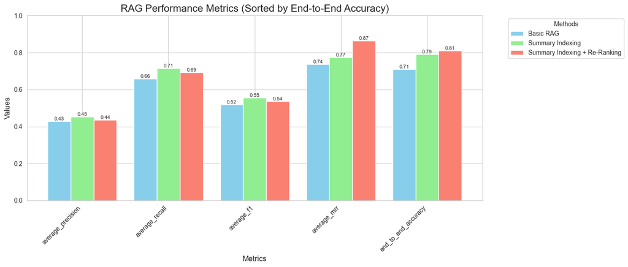

```python
# visualizing our performance
plot_performance(
    "evaluation/json_results",
    ["Basic RAG", "Summary Indexing", "Summary Indexing + Re-Ranking"],
    colors=["skyblue", "lightgreen", "salmon"],
)
```

## 평가 — Promptfoo로 더 깊이 들어가기

이 가이드는 프롬프트 엔지니어링에서 프롬프트 성능을 경험적으로 측정하는 일이 얼마나 중요한지 보여 주었습니다. 프롬프트 엔지니어링에 대한 경험적 방법론은 관련 문서에서 더 읽어 볼 수 있습니다. 주피터 노트북은 프롬프트 엔지니어링을 시작하기에 좋지만, 데이터셋이 커지고 프롬프트가 많아질수록 함께 확장되는 도구를 활용하는 것이 중요합니다.

이 절에서는 오픈소스 LLM 평가 도구인 Promptfoo를 살펴봅니다. 시작하려면 ./evaluation 디렉터리로 가서 ./evaluation/README.md를 확인하세요.

Promptfoo를 사용하면 서로 다른 모델, 하이퍼파라미터 선택, 프롬프트를 비교하는 자동화된 테스트 스위트를 아주 쉽게 만들 수 있습니다.

예를 들어 아래 셀을 실행하면 모든 테스트 케이스에 걸친 Haiku와 3.5 Sonnet의 평균 성능을 볼 수 있습니다.

```python
import json

import numpy as np
import pandas as pd

# Load the JSON file
with open("data/end_to_end_results.json") as f:
    data = json.load(f)

# Extract the results
results = data["results"]["results"]

# Create a DataFrame
df = pd.DataFrame(results)

# Extract provider, prompt, and score information
df["provider"] = df["provider"].apply(lambda x: x["label"] if isinstance(x, dict) else x)
df["prompt"] = df["prompt"].apply(lambda x: x["label"] if isinstance(x, dict) else x)


# Function to safely extract scores
def extract_score(x):
    if isinstance(x, dict) and "score" in x:
        return x["score"] * 100  # Convert to percentage
    return np.nan


df["score"] = df["gradingResult"].apply(extract_score)

# Group by provider and prompt, then calculate mean scores
result = df.groupby(["provider", "prompt"])["score"].mean().unstack()

# Fill NaN values with 0
result = result.fillna(0)

# Calculate the average score across all prompts for each provider
result["Average"] = result.mean(axis=1)

# Sort the result by the average score
result = result.sort_values(by="Average", ascending=False)

# Round the results to 2 decimal places
result = result.round(2)
# Calculate overall statistics
overall_average = result["Average"].mean()
overall_std = result["Average"].std()
best_provider = result["Average"].idxmax()
worst_provider = result["Average"].idxmin()

print("\nOverall Statistics:")
print(f"Best Performing Provider: {best_provider} ({result.loc[best_provider, 'Average']:.2f}%)")
print(f"Worst Performing Provider: {worst_provider} ({result.loc[worst_provider, 'Average']:.2f}%)")
```

```
Overall Statistics:
Best Performing Provider: 3.5 Sonnet: T-0.0 (85.00%)
Worst Performing Provider: Haiku: T-0.0 (78.00%)
```